# final project

Maria Tkachuk

# Practical Machine Learning - Course Project

## Introduction

For this project, we are given data from accelerometers on the belt, forearm, arm, and dumbell of 6 research study participants. Our training data consists of accelerometer data and a label identifying the quality of the activity the participant was doing. Our testing data consists of accelerometer data without the identifying label. Our goal is to predict the labels for the test set observations.

Below is the code I used when creating the model, estimating the out-of-sample error, and making predictions. I also include a description of each step of the process.

Data Preparation I load the caret package, and read in the training and testing data:

```r
library(caret)
train <- read.csv("C:\\Users\\mariat\\Downloads\\pml-training.csv")
test <- read.csv("C:\\Users\\mariat\\Downloads\\pml-testing.csv")
```

## Pre-processing

We need to pre-process our data before we can use it for modeling. Let’s check if the data has any missing values:

```r
sum(is.na(train))
```

```
## [1] 1287472
```

```r
# remove variables with nearly zero variance
inTrain<-createDataPartition(y=train$classe,p=0.7,list=FALSE)
train1<-train[inTrain,]
test1<-train[-inTrain,]
nzvtrain <- nearZeroVar(train1)
nzvtest<-nearZeroVar(test1)
train_processed <- train1[, -nzvtrain]
test_processed<-test1[,-nzvtest]

# remove variables that are almost always NA
mostlyNAtrain <- sapply(train_processed, function(x) mean(is.na(x))) > 0.95
train_processed <- train_processed[, mostlyNAtrain==F]
mostlyNAtest <- sapply(test_processed, function(x) mean(is.na(x))) > 0.95
test_processed <- test_processed[, mostlyNAtest==F]


# remove variables that don't make intuitive sense for prediction (X, user_name, raw_timestamp_part_1, raw_timestamp_part_2, cvtd_timestamp), which happen to be the first five variables
train_processed <- train_processed[, -(1:5)]
test_processed<-test_processed[,-(1:5)]
```

## Prediction with Decision Trees

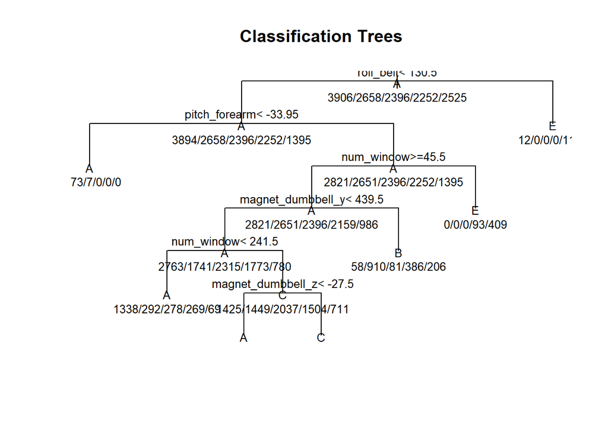

```r
set.seed(1222)
library(rpart)
fitRpart<-train(classe ~.,data=train_processed,method='rpart')

plot(fitRpart$finalModel,uniform=TRUE,main='Classification Trees')
text(fitRpart$finalModel,use.n=TRUE,all=TRUE,cex=.8)
```

```r
predRpart<-predict(fitRpart,test_processed)
cM<-confusionMatrix(predRpart,test_processed$classe)
cM
```

```
## Confusion Matrix and Statistics
##
##           Reference
## Prediction    A    B    C    D    E
##          A 1463  306  146  151   36
##          B   23  376   27  182   69
##          C  186  457  853  578  312
##          D    0    0    0    0    0
##          E    2    0    0   53  665
##
## Overall Statistics
##
##                Accuracy : 0.5704
##                  95% CI : (0.5577, 0.5831)
##     No Information Rate : 0.2845
##     P-Value [Acc > NIR] : < 2.2e-16
##
##                   Kappa : 0.4514
##  Mcnemar's Test P-Value : < 2.2e-16
##
## Statistics by Class:
##
##                      Class: A Class: B Class: C Class: D Class: E
## Sensitivity            0.8740  0.33011   0.8314   0.0000   0.6146
## Specificity            0.8483  0.93658   0.6845   1.0000   0.9885
## Pos Pred Value         0.6960  0.55539   0.3575      NaN   0.9236
## Neg Pred Value         0.9442  0.85349   0.9506   0.8362   0.9193
## Prevalence             0.2845  0.19354   0.1743   0.1638   0.1839
## Detection Rate         0.2486  0.06389   0.1449   0.0000   0.1130
## Detection Prevalence   0.3572  0.11504   0.4054   0.0000   0.1223
## Balanced Accuracy      0.8611  0.63335   0.7579   0.5000   0.8016
```

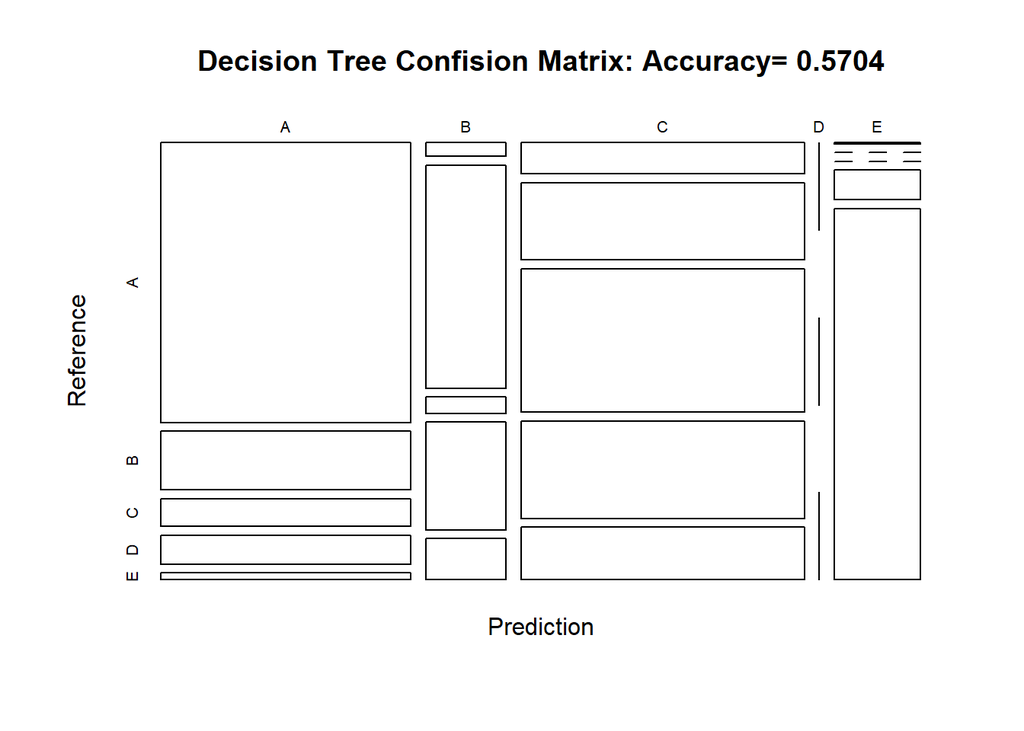

```r
plot(cM$table,col=cM$byClass,main=paste('Decision Tree Confision Matrix: Accuracy=',round(cM$overall['Accuracy'],4)))
```

## Random Forest Prediction

I fit the model on train_processed, and instruct the “train” function to use 3-fold cross-validation to select optimal tuning parameters for the model.

```r
# instruct train to use 3-fold CV to select optimal tuning parameters
fitControl <- trainControl(method="cv", number=3, verboseIter=F)

# fit model on ptrain1
fit <- train(classe ~ ., data=train_processed, method="rf", trControl=fitControl)


# print final model to see tuning parameters it chose
fit$finalModel
```

```
##
## Call:
##  randomForest(x = x, y = y, mtry = param$mtry)
##                Type of random forest: classification
##                      Number of trees: 500
## No. of variables tried at each split: 27
##
##         OOB estimate of  error rate: 0.17%
## Confusion matrix:
##      A    B    C    D    E  class.error
## A 3905    1    0    0    0 0.0002560164
## B    4 2653    1    0    0 0.0018811136
## C    0    4 2392    0    0 0.0016694491
## D    0    0    9 2242    1 0.0044404973
## E    0    0    0    4 2521 0.0015841584
```

## Model Evaluation and Selection

Now, I use the fitted model to predict the label (“classe”) in test_processed, and show the confusion matrix to compare the predicted versus the actual labels:

```r
# use model to predict classe in validation set (ptrain2)
preds <- predict(fit, newdata=test_processed)

# show confusion matrix to get estimate of out-of-sample error
confusionMatrix(test_processed$classe, preds)
```

```
## Confusion Matrix and Statistics
##
##           Reference
## Prediction    A    B    C    D    E
##          A 1674    0    0    0    0
##          B    2 1133    4    0    0
##          C    0    3 1023    0    0
##          D    0    0    2  962    0
##          E    0    2    0    0 1080
##
## Overall Statistics
##
##                Accuracy : 0.9978
##                  95% CI : (0.9962, 0.9988)
##     No Information Rate : 0.2848
##     P-Value [Acc > NIR] : < 2.2e-16
##
##                   Kappa : 0.9972
##  Mcnemar's Test P-Value : NA
##
## Statistics by Class:
##
##                      Class: A Class: B Class: C Class: D Class: E
## Sensitivity            0.9988   0.9956   0.9942   1.0000   1.0000
## Specificity            1.0000   0.9987   0.9994   0.9996   0.9996
## Pos Pred Value         1.0000   0.9947   0.9971   0.9979   0.9982
## Neg Pred Value         0.9995   0.9989   0.9988   1.0000   1.0000
## Prevalence             0.2848   0.1934   0.1749   0.1635   0.1835
## Detection Rate         0.2845   0.1925   0.1738   0.1635   0.1835
## Detection Prevalence   0.2845   0.1935   0.1743   0.1638   0.1839
## Balanced Accuracy      0.9994   0.9972   0.9968   0.9998   0.9998
```

The accuracy is 99.7%, thus my predicted accuracy for the out-of-sample error is 0.2%.

This is an excellent result, so rather than trying additional algorithms, I will use Random Forests to predict on the test set.

## Re-training the Selected Model

Before predicting on the test set, it is important to train the model on the full training set (train), rather than using a model trained on a reduced training set (train_procesesd), in order to produce the most accurate predictions.

```r
# re-fit model using full training set (train)
nzv<- nearZeroVar(train)

train1 <- train[, -nzv]
test1<-test[,-nzv]

# remove variables that are almost always NA
mostlyNAtrain <- sapply(train1, function(x) mean(is.na(x))) > 0.95
train1 <- train1[, mostlyNAtrain==F]
mostlyNAtest <- sapply(test1, function(x) mean(is.na(x))) > 0.95
test1 <- test1[, mostlyNAtest==F]


# remove variables that don't make intuitive sense for prediction (X, user_name, raw_timestamp_part_1, raw_timestamp_part_2, cvtd_timestamp), which happen to be the first five variables
train1 <- train1[, -(1:5)]
test1<-test1[,-(1:5)]
fitControl <- trainControl(method="cv", number=3, verboseIter=F)
fit <- train(classe ~ ., data=train1, method="rf", trControl=fitControl)
```

Making Test Set Predictions Now, I use the model fit on train to predict the label for the observations in test, and write those predictions to individual files:

```r
# predict on test set
preds <- predict(fit, newdata=test1)

# convert predictions to character vector
preds <- as.character(preds)

# create function to write predictions to files
pml_write_files <- function(x) {
    n <- length(x)
    for(i in 1:n) {
        filename <- paste0("problem_id_", i, ".txt")
        write.table(x[i], file=filename, quote=F, row.names=F, col.names=F)
    }
}

# create prediction files to submit
pml_write_files(preds)
```